# The Adult Impact of Childhood VCUGs

BMIN503/EPID600 Final Project

Author

Andrea McDonald

## 1 Overview

*Citations and references available upon request*

**An exploratory study on the adult impact of childhood VCUGs**

A Voiding Cystourethrogram (VCUG) is a diagnostic test that allows physicians to examine the urinary system, specifically the bladder and urethra. VCUGs are commonly performed in childhood to evaluate issues such as frequent urinary tract infections (UTIs), investigate abnormalities of the urinary system, or detect vesicoureteral reflux (a condition where urine flows backward from the bladder into the ureters).

The VCUG experience has been poorly documented in children; however, even less is known about the long-term impacts of the procedure. This project explores the prevalence and understanding of various sequelae among adults who underwent VCUG in childhood, while gaining insights into the lived experience of the procedure from the patient perspective.

To explore and understand these relationships, I use data collected from my own study “2023 VCUG Survey” (IRB Protocol #852632), in which responses were collected over nine months (January 2023 - September 2023). Respondents completed a 15-minute survey about their physical and mental health, and were categorized into two groups (“VCUG” and “control”) based on whether they did or did not report undergoing at least one VCUG in childhood (<18 years). I worked with Dr Bonnie Offit, MD and Scott Appel, Co-Director at the University of Pennsylvania Biostatistics Analysis Center, for this project. The preliminary findings from this project will inform next steps I will take in Spring 2024 as I look to publish my findings. For example, I must decide whether or not to incorporate findings from the control group in my published deliverable, or move this project forward as an exploratory research study focusing only on the VCUG group. This will depend on the presence of confounders, sample size, data collection methods, and physician input. Dr. Offit is serving as a physician consultant, advising on the nuances of VCUG ordering and the clinical perspective. Scott has opined on various ways to analyze the data, what might be criticized, and which statistical tests (if any) would be most appropriate for the variables collected.

[**Link to final project GitHub repository**](https://github.com/dremcdonald/DSFinalProject2023)

## 2 Introduction

### 2.1 Background of VCUG

Urinary tract infections (UTIs) are one of the most common bacterial infections in childhood, affecting approximately 7.8% of children <19 years with urinary symptoms and/or fever (16). Over 30% of children with UTI will have a recurrent episode (15). A common risk factor for recurrence is vesicoureteral reflux (VUR), a pediatric condition in which urine flows backward from the bladder back into the ureters and/or kidneys (16). VUR is important to identify as it leads to an increased risk of persistent and/or recurrent UTIs, and if left untreated, in some cases can cause kidney damage (6), though most children don’t have long-term problems from VUR as the condition frequently resolves on its own (17).

The Voiding Cystourethrogram (VCUG) is the primary diagnostic test used to diagnose VUR. As of 2021, there were approximately 73 million children under 18 in the United States (14). There are no confident estimates in the literature on the number of VCUGs performed nationwide, but from these figures, we can estimate that around 2 million children in the United States per year with recurrent UTIs may undergo at least one VCUG. This estimate does not consider a) cases where multiple VCUGs are performed on the same child within the year, and b) cases where a child undergoes VCUG after only one UTI. Expanding this estimate suggests that between 2 and 5 million children per year in the United States may become candidates for VCUG.

### 2.2 Lack of standardized VCUG protocols

VCUGs are ordered by many specialists and primary care providers, including pediatricians, family practitioners, nephrologists, hospitalists, emergency department physicians, and urologists (18), but protocols and standards for ordering and performing this test vary widely. In 2016, the AAP attempted to publish a consensus on how to perform and interpret VCUG, acknowledging that an official protocol has not been updated since 1985 (18). Still, no evidence-based or enforced protocol for VCUG exists (18). The AAP acknowledged that VCUG is one of the only imaging studies in existence that is regularly performed without national or international consensuses on process, raising concerns about patient safety and proper data/outcome comparisons. It also notes that the VCUG “can be traumatizing” for patients and parents alike, though it does not detail to what extent (18).

### 2.3 Depiction of VCUG

To perform a VCUG, children must remove their clothing and lie down on a table. Doctors clean the genital area and then insert a catheter to fill the bladder with contrast dye. The child must try to hold the contrast dye until they are no longer able to – after which they must ask to urinate on the table, often in front of multiple health care providers and their parents, while a fluoroscopy machine captures internal images of the body (21).

Most institutions describe VCUG as minimally invasive, painless, and without risks outside of standard imaging radiation exposure. However, as early as 1998, VCUGs were identified as potentially highly traumatic experiences. In 2004, VCUG patients were recruited as proxies for child sexual abuse victims<sup>4</sup> because “even doctors administering the procedure admit that in many ways the VCUG is similar to sexual assault on a child”<sup>5</sup>. An increasing volume of literature warns that the potential psychological trauma resulting from VCUG is analogous with that of a violent rape (19). A growing number of adults have advocated against the procedure and have begged for alternatives, citing decades-long PTSD, depression, broken relationships, and debilitating fear of sex, physical touch, and going to the bathroom. Some battle thoughts of suicide as a direct result of having undergone VCUG as children (8), though we cannot confirm how many.

Until now, no study has ever examined adults who underwent VCUG in childhood to assess whether the procedure has materially affected their lives.

## 3 Methods - Data Collection

[Step through the survey as if you were a participant here.](https://redcap.link/pcejwgr7)

### 3.1 Project Aim

This work seeks to:

a) Define two cohorts – VCUG and control;

b) Perform exploratory data analysis to inform whether the sample collected allows for statistical analysis between the VCUG and control groups;

c) Perform chosen analyses on VCUG and/or control group(s).

### 3.2 A Note on Previous Data Cleaning History

Certain data cleaning steps were performed in Excel/REDCap prior to this project. Those steps are enumerated below:

- Removed rows with duplicate entries from the same email; kept either the most complete, or the latest entry
- Removed “test” entries
- Removed respondents who exited survey before completing the main survey
- Removed identifiable information such as email addresses

## 4 Analysis Methods & Results

### 4.1 Packages, Table, Inspection, Cleanup

Load the necessary packages (assuming they’re previously installed).

```r
# Load packages
library(tidyverse)
library(ggplot2)
library(dplyr)
```

Read in the raw data table.

```r
# Read in table.
t <- read.csv("C:\\Users\\mcdonalda2\\OneDrive - Children's Hospital of Philadelphia\\Desktop\\VCUG Study\\Data\\vcugdataraw.csv")
```

Perform some inspection.

```r
# Perform initial inspection of data.
str(t)
```

```
'data.frame':   334 obs. of  120 variables:
 $ record_id               : int  277 225 160 111 7 201 204 254 253 110 ...
 $ age                     : int  26 24 27 23 24 23 25 26 20 27 ...
 $ sex_at_birth            : int  1 2 2 2 2 2 2 1 2 2 ...
 $ education_level         : int  6 5 7 6 7 7 5 4 5 7 ...
 $ emp_working_ind         : int  1 1 0 1 0 1 1 1 0 1 ...
 $ emp_unemp_ind           : int  0 0 1 0 0 0 0 0 0 0 ...
 $ emp_looking_ind         : int  0 0 0 0 1 0 0 0 0 0 ...
 $ emp_notlooking_ind      : int  0 0 0 0 0 0 0 0 0 0 ...
 $ emp_retired_ind         : int  0 0 0 0 0 0 0 0 0 0 ...
 $ emp_disabled_ind        : int  0 0 0 0 0 0 0 0 0 0 ...
 $ emp_student_ind         : int  0 0 0 0 0 1 0 0 1 0 ...
 $ emp_other_ind           : int  0 0 0 0 0 0 0 0 0 0 ...
 $ race                    : int  5 5 1 5 5 5 5 2 5 5 ...
 $ survey_source           : int  2 7 2 4 4 7 7 2 6 4 ...
```

[output cut: 86 more lines]

Perform data cleanup to more effectively analyze my information.

```r
# Perform data cleanup on the main table.

# Change indicators to clarify sex at birth.
t$sex_at_birth <- factor(t$sex_at_birth, levels = c(1, 2), labels = c("male", "female"))

# Change indicators to clarify education level.
t$education_level <- factor(t$education_level, levels = c(1,2,3,4,5,6,7,8,9,10,11), labels = c("never attended","elementary","middle","high/ged","some college","associate","bachelor","master","professional","doctoral","other"))

# Change indicators to clarify race.
t$race <- factor(t$race, levels = c(1,2,3,4,5,6,7), labels = c("NAHPI","AIAN","asian","black or AA","white","HisLat","other"))


# Change indicators to clarify vcug case and control status.
t$vcug_indicator <- factor(t$vcug_indicator, levels = c(0, 1), labels = c("control", "vcug"))

# Change indicators to clarify survey source.
t$survey_source <- factor(t$survey_source, levels = c(1,2,3,4,5,6,7), labels = c("linkedin", "twitter","instagram","reddit","organization","WOM","other"))


# Now I want to convert all the other columns in my data frame that have only 0s and 1s to "no" and "yes". I confirmed this was appropriate for all remaining columns by verifying with the data dictionary.

# Create a function to identify columns that contain only 0s and 1s.
binary_cols <- sapply(t, function(x) all(x %in% c(0, 1)))
# Convert those columns to factors with 'No' and 'Yes' labels.
t[binary_cols] <- lapply(t[binary_cols], function(x) factor(x, levels = c(0, 1), labels = c("No", "Yes")))
```

### 4.2 Exploratory Data Analysis - Demographics

Perform some EDA to understand demographics of the dataset.

```r
# Look at some demographic splits.
table(t$vcug_indicator)
```

```
control    vcug
    130     204
```

```r
table(t$sex_at_birth)
```

```
  male female
   101    233
```

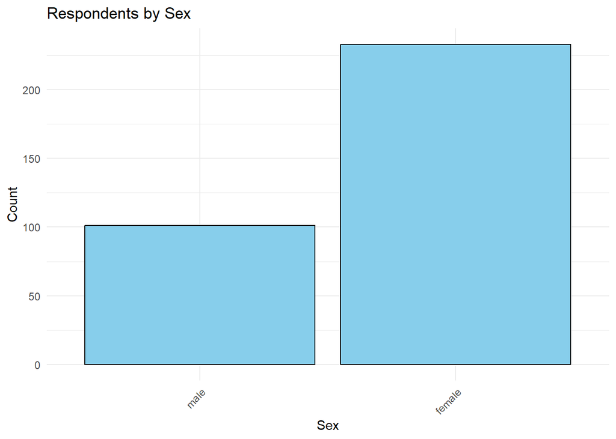

```r
# Bar chart of sex.
ggplot(t, aes(x = sex_at_birth)) +
  geom_bar(fill = "skyblue", color = "black") +
  labs(title = "Respondents by Sex", x = "Sex", y = "Count") +
  theme_minimal() +
  theme(axis.text.x = element_text(angle = 45, hjust = 1))
```

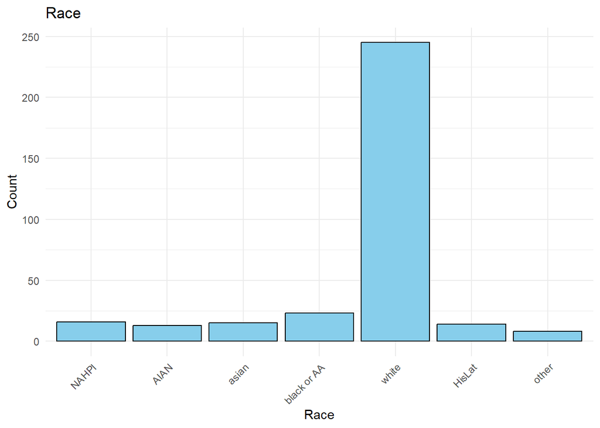

```r
# Bar chart of race distribution.
ggplot(t, aes(x = race)) +
  geom_bar(fill = "skyblue", color = "black") +
  labs(title = "Race", x = "Race", y = "Count") +
  theme_minimal() +
  theme(axis.text.x = element_text(angle = 45, hjust = 1))
```

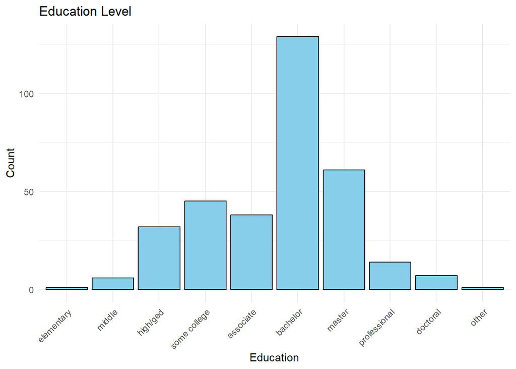

```r
# Bar chart of education level.
ggplot(t, aes(x = education_level)) +
  geom_bar(fill = "skyblue", color = "black") +
  labs(title = "Education Level", x = "Education", y = "Count") +
  theme_minimal() +
  theme(axis.text.x = element_text(angle = 45, hjust = 1))
```

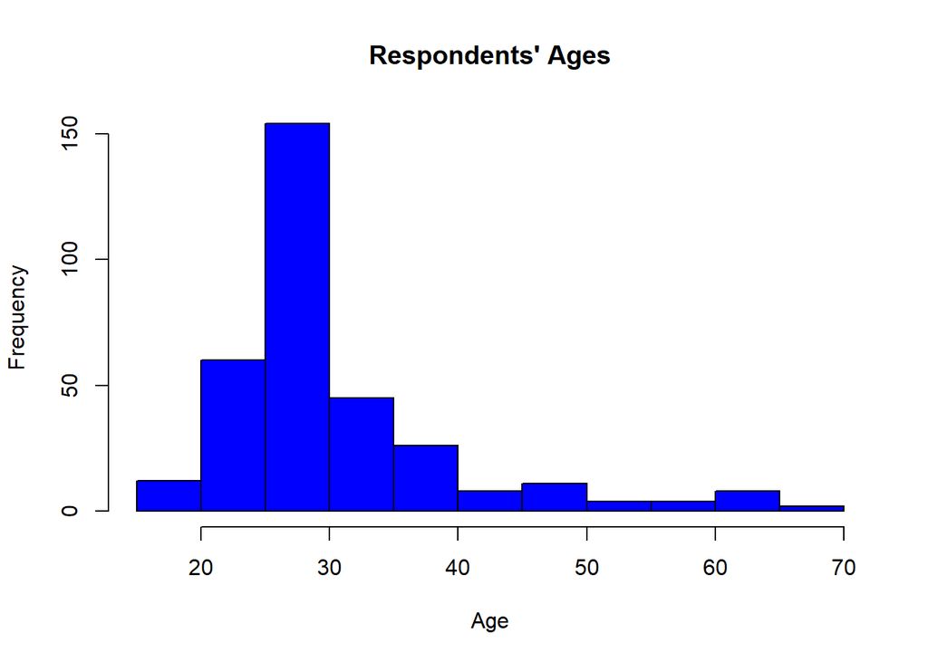

```r
# Histogram of age distribution.
hist(t$age, main = "Respondents' Ages", xlab = "Age", col = "blue")
```

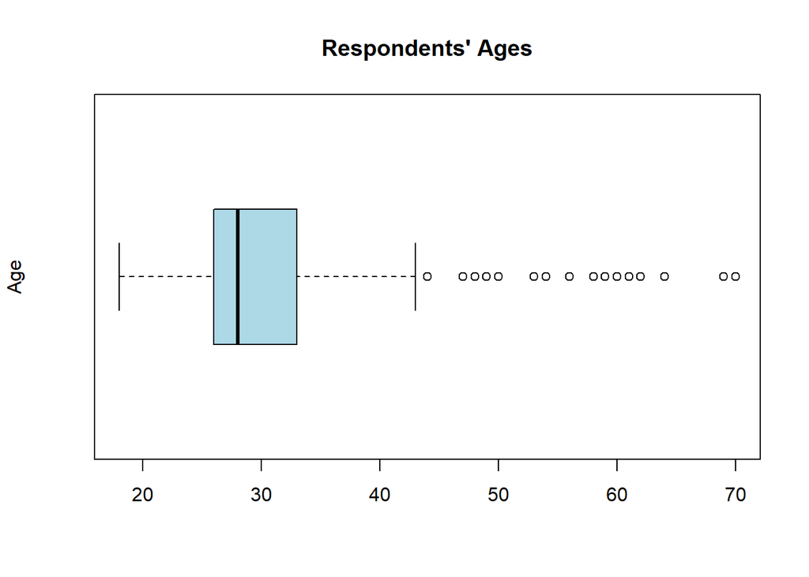

```r
# Box plot of age distribution.
boxplot(t$age, main = "Respondents' Ages", ylab = "Age", horizontal = TRUE, col = "lightblue")
```

```r
# Summary statistics of age range of respondents.
# Get minimum age, maximum age, mean, and median
min_age <- min(t$age, na.rm = TRUE)
max_age <- max(t$age, na.rm = TRUE)
mean_age <- mean(t$age, na.rm = TRUE)
median_age <- median(t$age, na.rm = TRUE)
# Print the summary statistics
cat("Min Age:", min_age, "\n")
```

```
Min Age: 18
```

```r
cat("Max Age:", max_age, "\n")
```

```
Max Age: 70
```

```r
cat("Mean Age:", mean_age, "\n")
```

```
Mean Age: 30.95808
```

```r
cat("Median Age:", median_age, "\n")
```

```
Median Age: 28
```

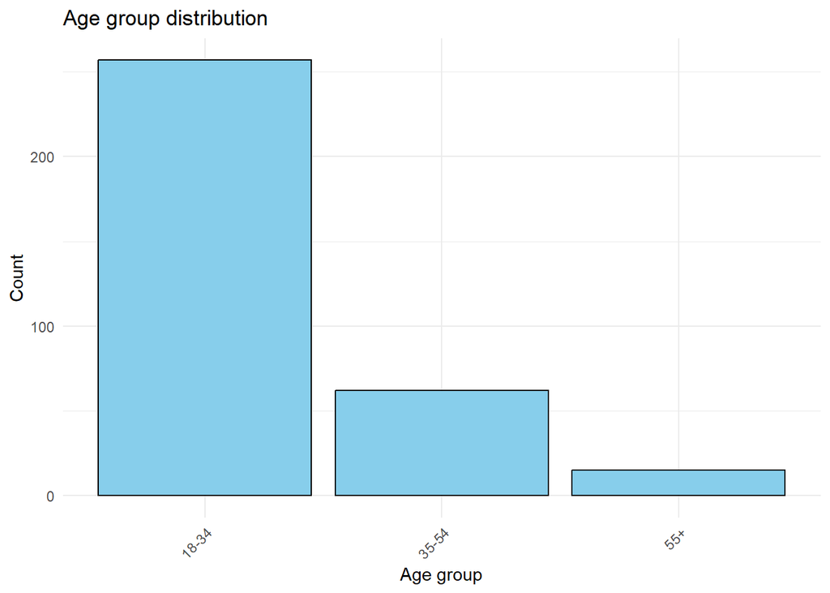

```r
# I want to bracket my age groups to get a better understanding of distribution.
# Define the breaks for the age groups
breaks <- c(17, 34, 54, Inf)  # Start with 17 to include 18 in the first bracket
# Define the labels for the age groups
labels <- c("18-34", "35-54", "55+")
# Create the age group column
t$age_group <- cut(t$age, breaks = breaks, labels = labels, right = FALSE)

# Bar chart of age groups.
ggplot(t, aes(x = age_group)) +
  geom_bar(fill = "skyblue", color = "black") +
  labs(title = "Age group distribution", x = "Age group", y = "Count") +
  theme_minimal() +
  theme(axis.text.x = element_text(angle = 45, hjust = 1))
```

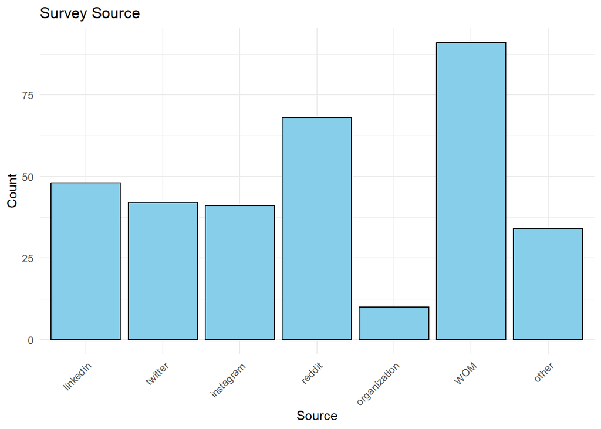

```r
# What was the source that my respondents found my survey from?
ggplot(t, aes(x = survey_source)) +
  geom_bar(fill = "skyblue", color = "black") +
  labs(title = "Survey Source", x = "Source", y = "Count") +
  theme_minimal() +
  theme(axis.text.x = element_text(angle = 45, hjust = 1))
```

**Takeaways:**

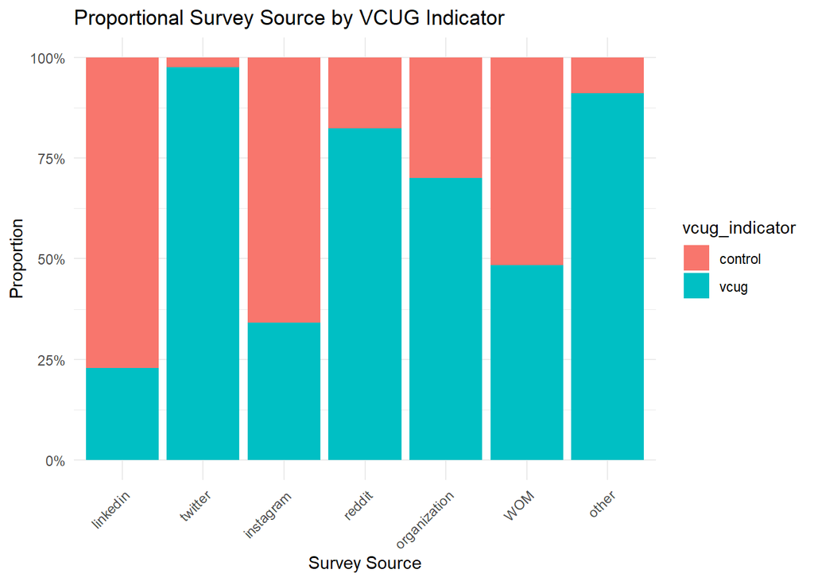

```r
# I want to dig into the source further because it's important. I will split my source by VCUG and controls.

# Survey source by VCUG indicator
ggplot(t, aes(x = survey_source, fill = vcug_indicator)) +
  geom_bar(position = "fill") +
  scale_y_continuous(labels = scales::percent_format()) +  # Convert y-axis to percent
  labs(title = "Proportional Survey Source by VCUG Indicator",
       x = "Survey Source",
       y = "Proportion") +
  theme_minimal() +
  theme(axis.text.x = element_text(angle = 45, hjust = 1))  # Rotate x labels for better readability
```

This proportion distribution shows that my VCUG and control groups heard about my survey through pretty different sources, suggesting quite a bit of bias in my sample. I would ideally like this graph to look 50/50 in distribution, knowing what I know about Reddit as a source.

Let’s dig in further. I want to do some stratified summary statistics to see if I collected comparable data from other demographic perspectives across my VCUG and control group splits.

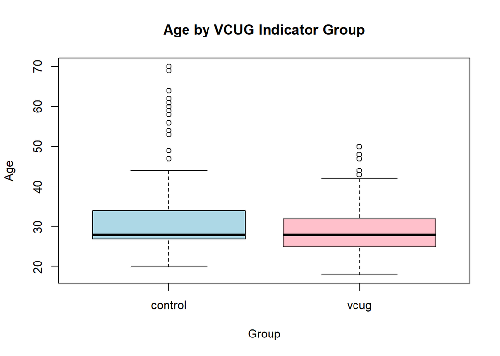

```r
# Boxplot of age by VCUG indicator group
boxplot(age ~ vcug_indicator, data = t, main = "Age by VCUG Indicator Group",
        xlab = "Group", ylab = "Age", col = c("lightblue", "pink"))
```

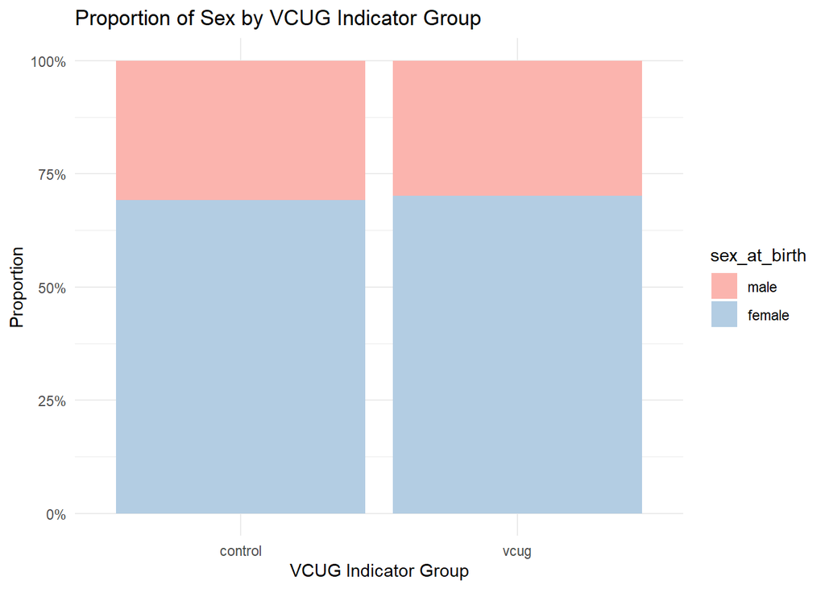

```r
# Bar chart of sex by VCUG indicator group, proportional
# Create a bar chart with proportions
ggplot(t, aes(x = vcug_indicator, fill = sex_at_birth)) +
  geom_bar(position = "fill") +
  scale_y_continuous(labels = scales::percent) + # Convert y-axis to percent
  labs(title = "Proportion of Sex by VCUG Indicator Group",
       x = "VCUG Indicator Group",
       y = "Proportion") +
  scale_fill_brewer(palette = "Pastel1") +
  theme_minimal()
```

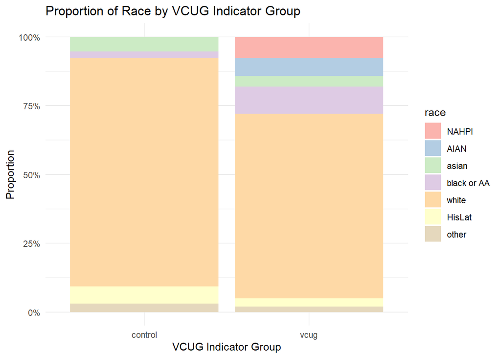

```r
# Bar chart of race by VCUG indicator group, proportional
# Create a bar chart with proportions
ggplot(t, aes(x = vcug_indicator, fill = race)) +
  geom_bar(position = "fill") +
  scale_y_continuous(labels = scales::percent) + # Convert y-axis to percent
  labs(title = "Proportion of Race by VCUG Indicator Group",
       x = "VCUG Indicator Group",
       y = "Proportion") +
  scale_fill_brewer(palette = "Pastel1") +
  theme_minimal()
```

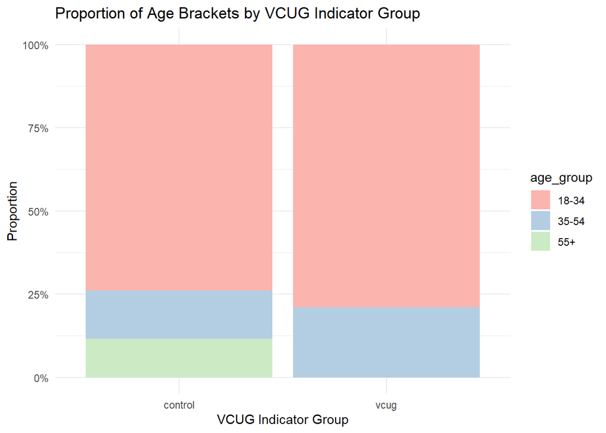

```r
# Bar chart of age group by VCUG indicator, proportional
# Create a bar chart with proportions
ggplot(t, aes(x = vcug_indicator, fill = age_group)) +
  geom_bar(position = "fill") +
  scale_y_continuous(labels = scales::percent) + # Convert y-axis to percent
  labs(title = "Proportion of Age Brackets by VCUG Indicator Group",
       x = "VCUG Indicator Group",
       y = "Proportion") +
  scale_fill_brewer(palette = "Pastel1") +
  theme_minimal()
```

**Takeaways:**

- Stratified sex distribution was balanced, though leaning female.
- Stratified age distribution was balanced, concentrated in the 18-35 range for both groups. Control group saw more outliers in older age brackets.
- My VCUG group is more diverse than my control group, but not by too much. Overall, the sample is heavily white-leaning, which needs improvement if we were to repeat this study.

### 4.3 Data Analysis - *How would you rate your overall physical and mental health?*

I want to analyze how healthy the respondents in each group perceive themselves to be, by looking at the distribution and relationship of these self-reported health ratings within the case and control groups.

```r
# Create a new table with selected columns
health_rating <- t %>%
  select(vcug_indicator, phys_health_rating, ment_health_rating)

# Summary statistics for physical and mental health ratings stratified by VCUG indicator
health_stats <- health_rating %>%
  group_by(vcug_indicator) %>%
  summarise(
    phys_health_mean = mean(phys_health_rating, na.rm = TRUE),
    phys_health_sd = sd(phys_health_rating, na.rm = TRUE),
    phys_health_median = median(phys_health_rating, na.rm = TRUE),
    ment_health_mean = mean(ment_health_rating, na.rm = TRUE),
    ment_health_sd = sd(ment_health_rating, na.rm = TRUE),
    ment_health_median = median(ment_health_rating, na.rm = TRUE),
  )

print(health_stats)
```

```
# A tibble: 2 × 7
  vcug_indicator phys_health_mean phys_health_sd phys_health_median
  <fct>                     <dbl>          <dbl>              <dbl>
1 control                    72.6           18.9                 76
2 vcug                       63.4           22.5                 67
# ℹ 3 more variables: ment_health_mean <dbl>, ment_health_sd <dbl>,
#   ment_health_median <dbl>
```

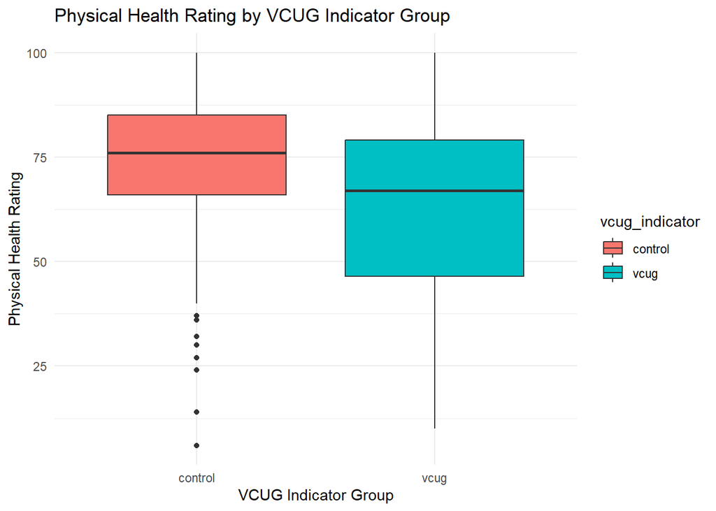

```r
# Visual Comparisons

# Physical Health Rating Boxplot
ggplot(health_rating, aes(x = vcug_indicator, y = phys_health_rating, fill = vcug_indicator)) +
  geom_boxplot() +
  labs(title = "Physical Health Rating by VCUG Indicator Group",
       x = "VCUG Indicator Group",
       y = "Physical Health Rating") +
  theme_minimal()
```

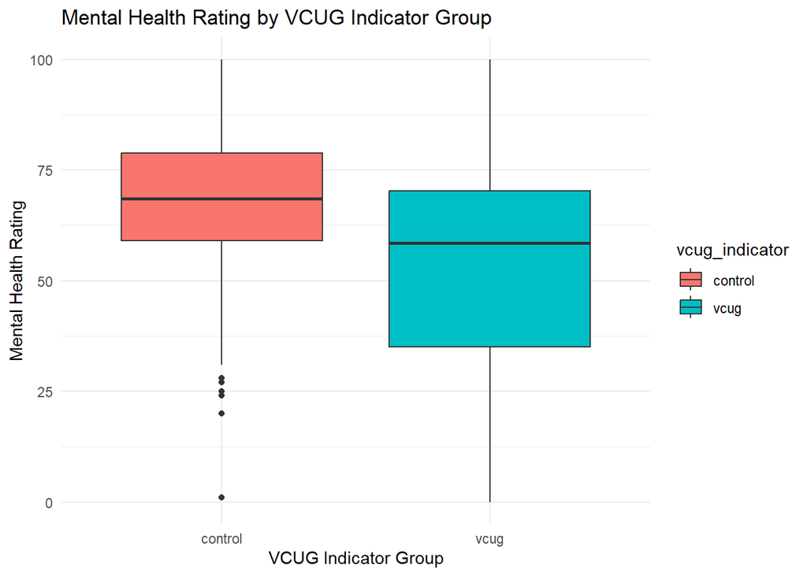

```r
# Mental Health Rating Boxplot
ggplot(health_rating, aes(x = vcug_indicator, y = ment_health_rating, fill = vcug_indicator)) +
  geom_boxplot() +
  labs(title = "Mental Health Rating by VCUG Indicator Group",
       x = "VCUG Indicator Group",
       y = "Mental Health Rating") +
  theme_minimal()
```

**Takeaways:**

- Both physical and mental health are self-reported lower in the VCUG group than the control group.

### 4.4 Data Analysis - *Have you ever been diagnosed with…?*

The following section explores whether respondents have been diagnosed with, or think they might have: depression, anxiety, bipolar disorder, PTSD, OCD, misophonia, PGAD, and/or HPF. Disease explanations can be found in the data dictionary.

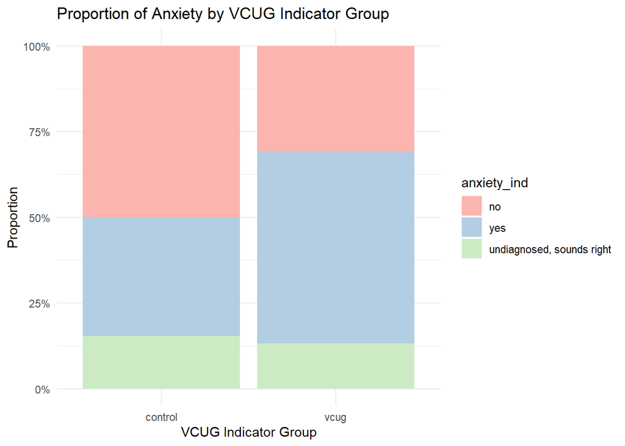

```r
# Create a new table with selected columns
diagnoses <- t %>%
  select(vcug_indicator, anxiety_ind, depression_ind, bipolar_ind, ptsd_ind, ocd_ind, misophonia_ind, pgad_ind, hpf_ind)

# Change indicators to clarify 1 = no, 2 = yes, 3 = undiagnosed but sounds like something i might have.
diagnoses$anxiety_ind <- factor(diagnoses$anxiety_ind, levels = c(1, 2, 3), labels = c("no", "yes", "undiagnosed, sounds right"))

diagnoses$depression_ind <- factor(diagnoses$depression_ind, levels = c(1, 2, 3), labels = c("no", "yes", "undiagnosed, sounds right"))

diagnoses$bipolar_ind <- factor(diagnoses$bipolar_ind, levels = c(1, 2, 3), labels = c("no", "yes", "undiagnosed, sounds right"))

diagnoses$ptsd_ind <- factor(diagnoses$ptsd_ind, levels = c(1, 2, 3), labels = c("no", "yes", "undiagnosed, sounds right"))

diagnoses$ocd_ind <- factor(diagnoses$ocd_ind, levels = c(1, 2, 3), labels = c("no", "yes", "undiagnosed, sounds right"))

diagnoses$misophonia_ind <- factor(diagnoses$misophonia_ind, levels = c(1, 2, 3), labels = c("no", "yes", "undiagnosed, sounds right"))

diagnoses$pgad_ind <- factor(diagnoses$pgad_ind, levels = c(1, 2, 3), labels = c("no", "yes", "undiagnosed, sounds right"))

diagnoses$hpf_ind <- factor(diagnoses$hpf_ind, levels = c(1, 2, 3), labels = c("no", "yes", "undiagnosed, sounds right"))


# Bar chart of anxiety by VCUG indicator, proportional
# Create a bar chart with proportions
ggplot(diagnoses, aes(x = vcug_indicator, fill = anxiety_ind)) +
  geom_bar(position = "fill") +
  scale_y_continuous(labels = scales::percent) + # Convert y-axis to percent
  labs(title = "Proportion of Anxiety by VCUG Indicator Group",
       x = "VCUG Indicator Group",
       y = "Proportion") +
  scale_fill_brewer(palette = "Pastel1") +
  theme_minimal()
```

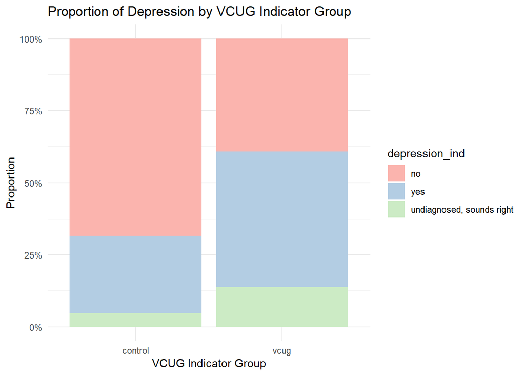

```r
# Bar chart of depression by VCUG indicator, proportional
# Create a bar chart with proportions
ggplot(diagnoses, aes(x = vcug_indicator, fill = depression_ind)) +
  geom_bar(position = "fill") +
  scale_y_continuous(labels = scales::percent) + # Convert y-axis to percent
  labs(title = "Proportion of Depression by VCUG Indicator Group",
       x = "VCUG Indicator Group",
       y = "Proportion") +
  scale_fill_brewer(palette = "Pastel1") +
  theme_minimal()
```

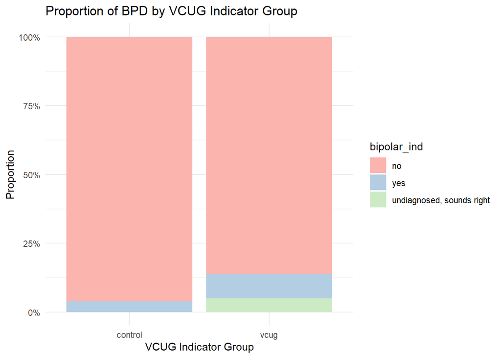

```r
# Bar chart of bipolar by VCUG indicator, proportional
# Create a bar chart with proportions
ggplot(diagnoses, aes(x = vcug_indicator, fill = bipolar_ind)) +
  geom_bar(position = "fill") +
  scale_y_continuous(labels = scales::percent) + # Convert y-axis to percent
  labs(title = "Proportion of BPD by VCUG Indicator Group",
       x = "VCUG Indicator Group",
       y = "Proportion") +
  scale_fill_brewer(palette = "Pastel1") +
  theme_minimal()
```

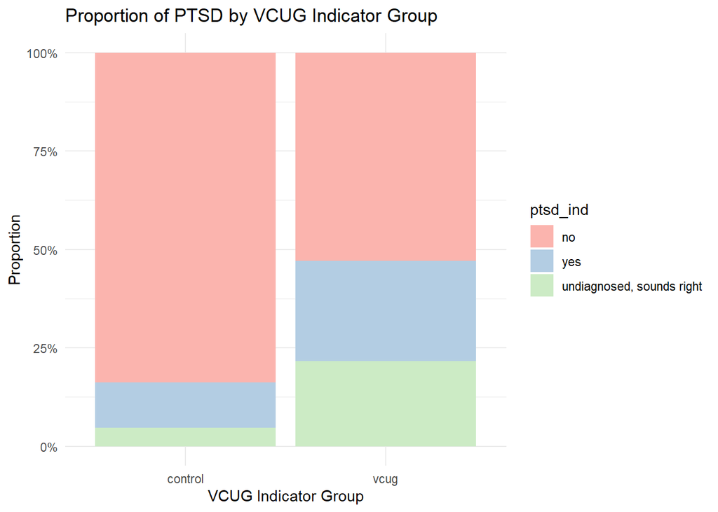

```r
# Bar chart of PTSD by VCUG indicator, proportional
# Create a bar chart with proportions
ggplot(diagnoses, aes(x = vcug_indicator, fill = ptsd_ind)) +
  geom_bar(position = "fill") +
  scale_y_continuous(labels = scales::percent) + # Convert y-axis to percent
  labs(title = "Proportion of PTSD by VCUG Indicator Group",
       x = "VCUG Indicator Group",
       y = "Proportion") +
  scale_fill_brewer(palette = "Pastel1") +
  theme_minimal()
```

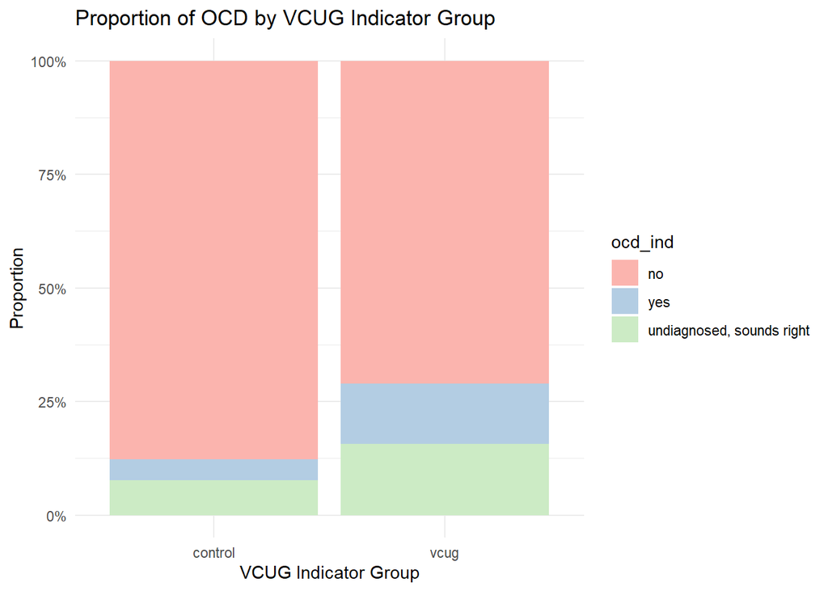

```r
# Bar chart of OCD by VCUG indicator, proportional
# Create a bar chart with proportions
ggplot(diagnoses, aes(x = vcug_indicator, fill = ocd_ind)) +
  geom_bar(position = "fill") +
  scale_y_continuous(labels = scales::percent) + # Convert y-axis to percent
  labs(title = "Proportion of OCD by VCUG Indicator Group",
       x = "VCUG Indicator Group",
       y = "Proportion") +
  scale_fill_brewer(palette = "Pastel1") +
  theme_minimal()
```

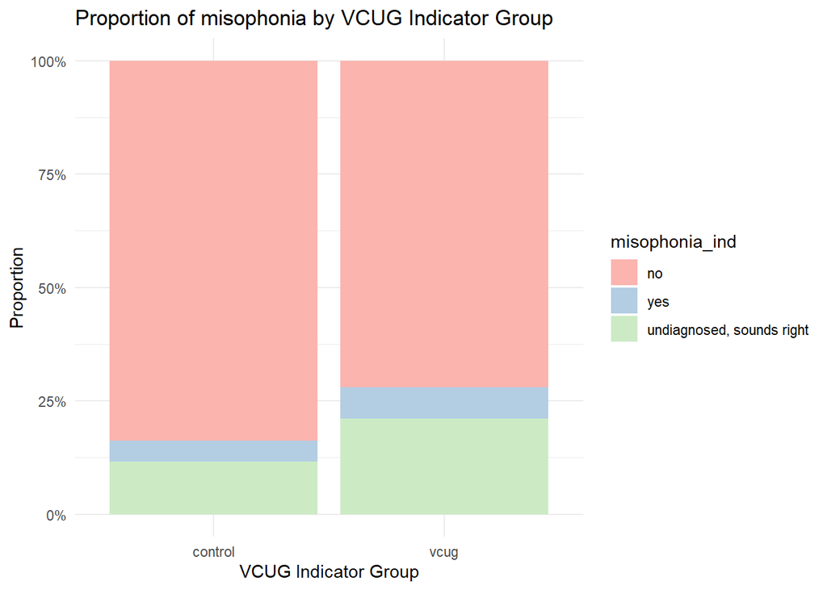

```r
# Bar chart of misophonia by VCUG indicator, proportional
# Create a bar chart with proportions
ggplot(diagnoses, aes(x = vcug_indicator, fill = misophonia_ind)) +
  geom_bar(position = "fill") +
  scale_y_continuous(labels = scales::percent) + # Convert y-axis to percent
  labs(title = "Proportion of misophonia by VCUG Indicator Group",
       x = "VCUG Indicator Group",
       y = "Proportion") +
  scale_fill_brewer(palette = "Pastel1") +
  theme_minimal()
```

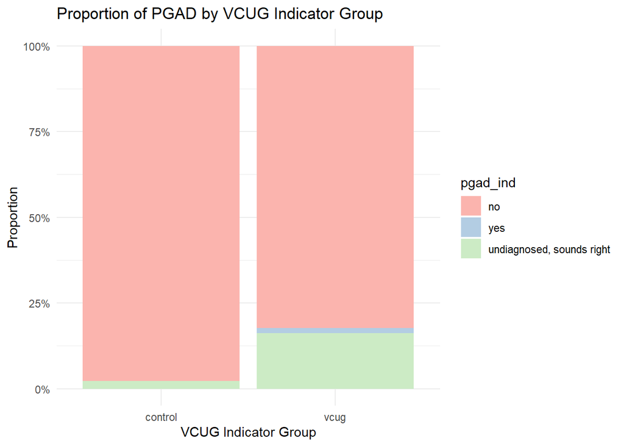

```r
# Bar chart of PGAD by VCUG indicator, proportional
# Create a bar chart with proportions
ggplot(diagnoses, aes(x = vcug_indicator, fill = pgad_ind)) +
  geom_bar(position = "fill") +
  scale_y_continuous(labels = scales::percent) + # Convert y-axis to percent
  labs(title = "Proportion of PGAD by VCUG Indicator Group",
       x = "VCUG Indicator Group",
       y = "Proportion") +
  scale_fill_brewer(palette = "Pastel1") +
  theme_minimal()
```

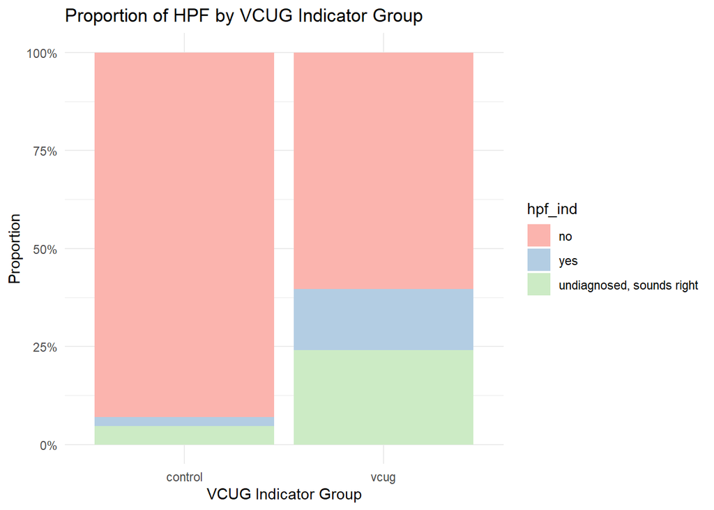

```r
# Bar chart of HPF by VCUG indicator, proportional
# Create a bar chart with proportions
ggplot(diagnoses, aes(x = vcug_indicator, fill = hpf_ind)) +
  geom_bar(position = "fill") +
  scale_y_continuous(labels = scales::percent) + # Convert y-axis to percent
  labs(title = "Proportion of HPF by VCUG Indicator Group",
       x = "VCUG Indicator Group",
       y = "Proportion") +
  scale_fill_brewer(palette = "Pastel1") +
  theme_minimal()
```

**Takeaways:**

- VCUG group returned a larger proportion of diagnoses or supposed diagnoses in every single category.

### 4.5 Data Analysis - Utilization of necessary and preventive healthcare services

Create the necessary tables for this analysis.

```r
# Create new tables with selected columns
preventive_care_both <- t %>%
  select(vcug_indicator, sex_at_birth, physician_care, urologist_care)

# Change indicators to clarify 1, Yes - I have before (at least once) | 2, No - Never have, but I will if I need to | 3, No - Never have, and I won't (even if I need to)
preventive_care_both$physician_care <- factor(preventive_care_both$physician_care, levels = c(1, 2, 3), labels = c("yes have", "no would", "never"))
preventive_care_both$urologist_care <- factor(preventive_care_both$urologist_care, levels = c(1, 2, 3), labels = c("yes have", "no would", "never"))

# Create new table and filter out branching logic, females only
preventive_care_female <- t %>%
  select(vcug_indicator, sex_at_birth, gyn_care, pap_smear_ind)

preventive_care_female <- preventive_care_female %>%
  filter(sex_at_birth != "male")

# Change indicators to clarify 1, Yes - I have before (at least once) | 2, No - Never have, but I will if I need to | 3, No - Never have, and I won't (even if I need to)
preventive_care_female$gyn_care <- factor(preventive_care_female$gyn_care, levels = c(1, 2, 3), labels = c("yes have", "no would", "never"))
preventive_care_female$pap_smear_ind <- factor(preventive_care_female$pap_smear_ind, levels = c(1, 2, 3), labels = c("yes have", "no would", "never"))
```

#### 4.5.1 *Do you see a physician for routine preventive care and/or physicals?*

Get the % of VCUG and % of controls (respectively) who responded “No - never will”

```r
# Percentage of "vcug" respondents that answered "never" to physician_care
phys_never_vcug <- preventive_care_both %>%
  filter(vcug_indicator == "vcug", physician_care == "never") %>%
  summarise(count_never = n()) %>%
  mutate(total_vcug = sum(preventive_care_both$vcug_indicator == "vcug"),
         percentage = (count_never / total_vcug) * 100)

# Percentage of "control" respondents that answered "never" to physician_care
phys_never_control <- preventive_care_both %>%
  filter(vcug_indicator == "control", physician_care == "never") %>%
  summarise(count_never = n()) %>%
  mutate(total_vcug = sum(preventive_care_both$vcug_indicator == "control"),
         percentage = (count_never / total_vcug) * 100)

phys_never_vcug
```

```
  count_never total_vcug percentage
1           7        204   3.431373
```

```r
phys_never_control
```

```
  count_never total_vcug percentage
1           2        130   1.538462
```

#### 4.5.2 *Do you see a gynecologist for routine preventive care (well-woman visits)?*

```r
# Percentage of "vcug" respondents that answered "never" to gyn_care
gyn_never_vcug <- preventive_care_female %>%
  filter(vcug_indicator == "vcug", gyn_care == "never") %>%
  summarise(count_never = n()) %>%
  mutate(total_vcug = sum(preventive_care_female$vcug_indicator == "vcug"),
         percentage = (count_never / total_vcug) * 100)

# Percentage of "control" respondents that answered "never" to gyn_care
gyn_never_control <- preventive_care_female %>%
  filter(vcug_indicator == "control", gyn_care == "never") %>%
  summarise(count_never = n()) %>%
  mutate(total_vcug = sum(preventive_care_female$vcug_indicator == "control"),
         percentage = (count_never / total_vcug) * 100)

gyn_never_vcug
```

```
  count_never total_vcug percentage
1          22        143   15.38462
```

```r
gyn_never_control
```

```
  count_never total_vcug percentage
1           2         90   2.222222
```

#### 4.5.3 *Have you ever received a pap smear as part of preventive gynecological care?*

```r
# Percentage of "vcug" female respondents that answered "never" to pap
pap_never_vcug <- preventive_care_female %>%
  filter(vcug_indicator == "vcug", pap_smear_ind == "never") %>%
  summarise(count_never = n()) %>%
  mutate(total_vcug = sum(preventive_care_female$vcug_indicator == "vcug"),
         percentage = (count_never / total_vcug) * 100)

# Percentage of "control" female respondents that answered "never" to pap
pap_never_control <- preventive_care_female %>%
  filter(vcug_indicator == "control", pap_smear_ind == "never") %>%
  summarise(count_never = n()) %>%
  mutate(total_vcug = sum(preventive_care_female$vcug_indicator == "control"),
         percentage = (count_never / total_vcug) * 100)

pap_never_vcug
```

```
  count_never total_vcug percentage
1          28        143   19.58042
```

```r
pap_never_control
```

```
  count_never total_vcug percentage
1           1         90   1.111111
```

#### 4.5.4 *Have you ever seen a urologist?*

```r
# Percentage of "vcug" respondents that answered "never" to urologist_care
ur_never_vcug <- preventive_care_both %>%
  filter(vcug_indicator == "vcug", urologist_care == "never") %>%
  summarise(count_never = n()) %>%
  mutate(total_vcug = sum(preventive_care_both$vcug_indicator == "vcug"),
         percentage = (count_never / total_vcug) * 100)

# Percentage of "control" respondents that answered "never" to urologist_care
ur_never_control <- preventive_care_both %>%
  filter(vcug_indicator == "control", urologist_care == "never") %>%
  summarise(count_never = n()) %>%
  mutate(total_vcug = sum(preventive_care_both$vcug_indicator == "control"),
         percentage = (count_never / total_vcug) * 100)

ur_never_vcug
```

```
  count_never total_vcug percentage
1          23        204   11.27451
```

```r
ur_never_control
```

```
  count_never total_vcug percentage
1           6        130   4.615385
```

- **Takeaways:** 11% of the VCUG group reported that they will never see a urologist, even if they need to (vs. 5% in the control group). 3% of the VCUG group reported that they will never see a physician (vs. 2% in the control group). 15% of the female VCUG group reported that they will never see a gynecologist (vs 2% of the control female group). 20% of the VCUG female group reported that they will never get a pap smear (vs 1% of the control female group).

### 4.6 Data Analysis - On a scale of 1-100, evaluate the following statements

```r
# Create appropriate data frame for this analysis

safety <- t %>%
  select(vcug_indicator, safe_int_rel_scale, parent_hugs, public_bathroom, general_bathroom, safe_body_scale, enjoy_sex)

# Summary statistics
summary(safety)
```

```
 vcug_indicator safe_int_rel_scale  parent_hugs    public_bathroom
 control:130    Min.   :  0.0      Min.   :  0.0   Min.   :  0.00
 vcug   :204    1st Qu.: 61.0      1st Qu.: 50.0   1st Qu.: 61.00
                Median : 82.0      Median : 73.0   Median : 85.00
                Mean   : 74.1      Mean   : 68.6   Mean   : 75.21
                3rd Qu.: 98.0      3rd Qu.: 98.0   3rd Qu.:100.00
                Max.   :100.0      Max.   :100.0   Max.   :100.00

 general_bathroom safe_body_scale    enjoy_sex
 Min.   :  0.00   Min.   :  0.00   Min.   :  0.00
 1st Qu.: 64.00   1st Qu.: 50.00   1st Qu.: 50.00
 Median : 90.50   Median : 76.50   Median : 77.00
 Mean   : 79.48   Mean   : 69.47   Mean   : 70.75
 3rd Qu.:100.00   3rd Qu.: 97.00   3rd Qu.: 99.25
 Max.   :100.00   Max.   :100.00   Max.   :100.00
                                   NA's   :6
```

#### 4.6.1 *I feel safe in long-term, intimate relationships with my partners.*

```r
# Summary statistics stratified by VCUG indicator
safe_int_rel_scale_stats <- safety %>%
  group_by(vcug_indicator) %>%
  summarise(
    safe_int_rel_scale_mean = mean(safe_int_rel_scale, na.rm = TRUE),
    safe_int_rel_scale_med = median(safe_int_rel_scale, na.rm = TRUE),
)
safe_int_rel_scale_stats
```

```
# A tibble: 2 × 3
  vcug_indicator safe_int_rel_scale_mean safe_int_rel_scale_med
  <fct>                            <dbl>                  <dbl>
1 control                           84.9                   96.5
2 vcug                              67.2                   70
```

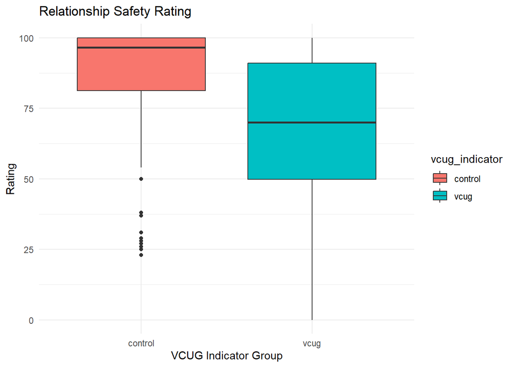

```r
# Rating Boxplot
ggplot(safety, aes(x = vcug_indicator, y = safe_int_rel_scale, fill = vcug_indicator)) +
  geom_boxplot() +
  labs(title = "Relationship Safety Rating",
       x = "VCUG Indicator Group",
       y = "Rating") +
  theme_minimal()
```

#### 4.6.2 *I am okay with hugs/physical contact from my parents/primary caregivers.*

```r
# Summary statistics stratified by VCUG indicator
parent_hugs_stats <- safety %>%
  group_by(vcug_indicator) %>%
  summarise(
    parent_hugs_mean = mean(parent_hugs, na.rm = TRUE),
    parent_hugs_med = median(parent_hugs, na.rm = TRUE),
)
parent_hugs_stats
```

```
# A tibble: 2 × 3
  vcug_indicator parent_hugs_mean parent_hugs_med
  <fct>                     <dbl>           <dbl>
1 control                    87.2            98.5
2 vcug                       56.8            63
```

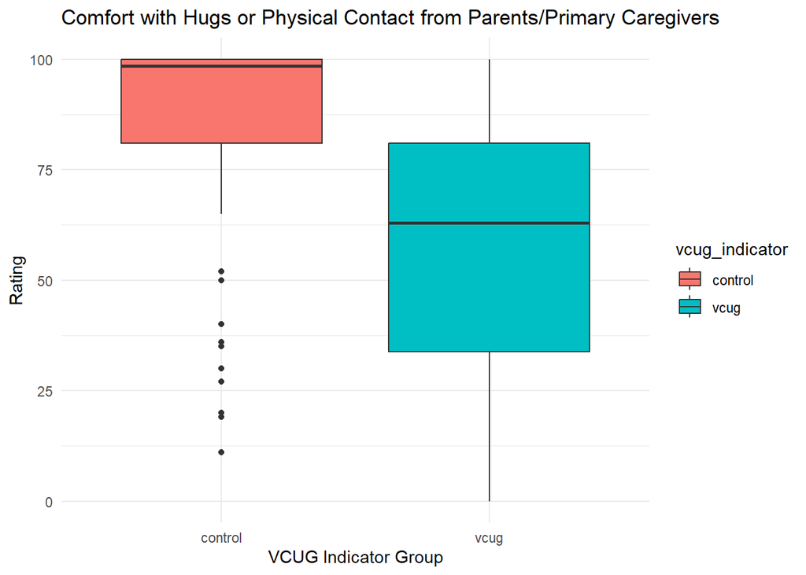

```r
# Rating Boxplot
ggplot(safety, aes(x = vcug_indicator, y = parent_hugs, fill = vcug_indicator)) +
  geom_boxplot() +
  labs(title = "Comfort with Hugs or Physical Contact from Parents/Primary Caregivers",
       x = "VCUG Indicator Group",
       y = "Rating") +
  theme_minimal()
```

*I am okay with going to the bathroom in a public restroom (like at the restaurant or the office).*

```r
# Summary statistics stratified by VCUG indicator
pb_stats <- safety %>%
  group_by(vcug_indicator) %>%
  summarise(
    pb_mean = mean(public_bathroom, na.rm = TRUE),
    pb_med = median(public_bathroom, na.rm = TRUE),
)
pb_stats
```

```
# A tibble: 2 × 3
  vcug_indicator pb_mean pb_med
  <fct>            <dbl>  <dbl>
1 control           86.7   97.5
2 vcug              67.9   69
```

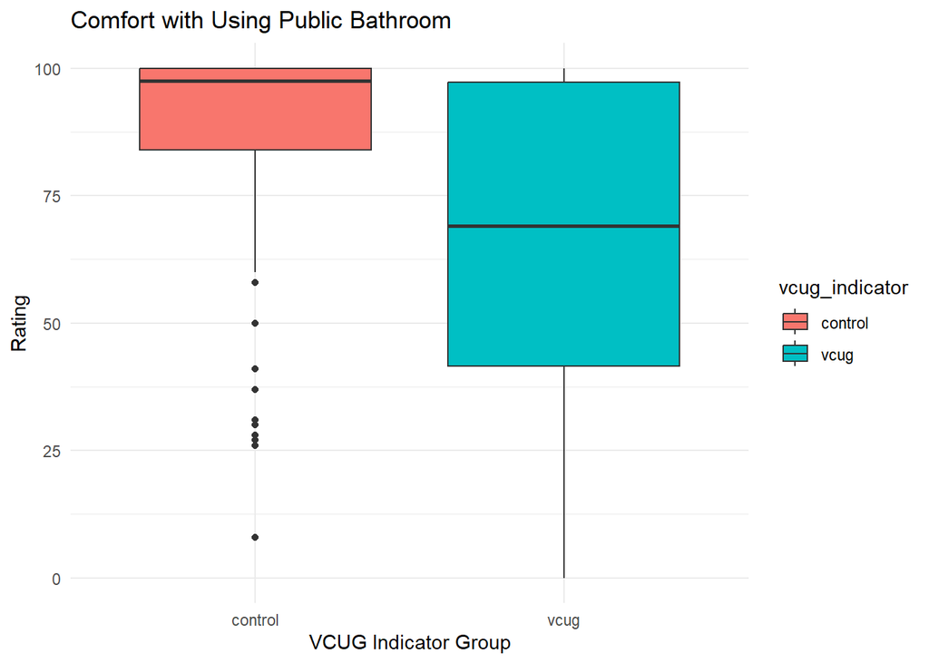

```r
# Rating Boxplot
ggplot(safety, aes(x = vcug_indicator, y = public_bathroom, fill = vcug_indicator)) +
  geom_boxplot() +
  labs(title = "Comfort with Using Public Bathroom",
       x = "VCUG Indicator Group",
       y = "Rating") +
  theme_minimal()
```

*I am comfortable going to the bathroom in general.*

```r
# Summary statistics stratified by VCUG indicator
gb_stats <- safety %>%
  group_by(vcug_indicator) %>%
  summarise(
    gb_mean = mean(general_bathroom, na.rm = TRUE),
    gb_med = median(general_bathroom, na.rm = TRUE),
)
gb_stats
```

```
# A tibble: 2 × 3
  vcug_indicator gb_mean gb_med
  <fct>            <dbl>  <dbl>
1 control           92.2     99
2 vcug              71.4     74
```

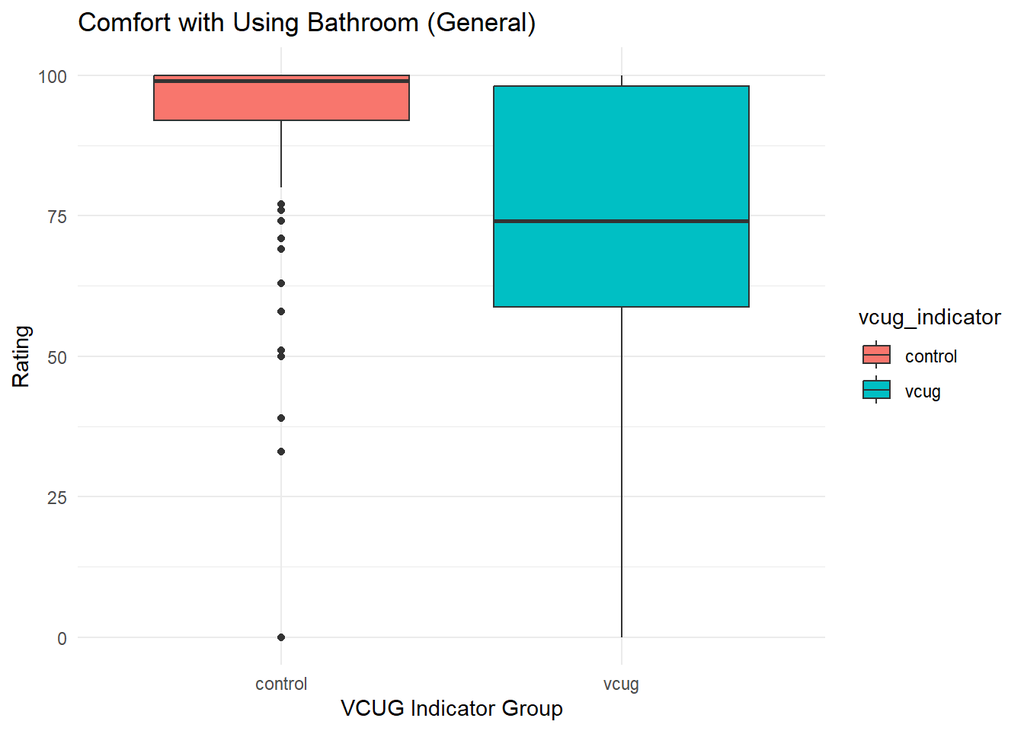

```r
# Rating Boxplot
ggplot(safety, aes(x = vcug_indicator, y = general_bathroom, fill = vcug_indicator)) +
  geom_boxplot() +
  labs(title = "Comfort with Using Bathroom (General)",
       x = "VCUG Indicator Group",
       y = "Rating") +
  theme_minimal()
```

*I feel safe in my own body.*

```r
# Summary statistics stratified by VCUG indicator
safebody_stats <- safety %>%
  group_by(vcug_indicator) %>%
  summarise(
    safebody_mean = mean(safe_body_scale, na.rm = TRUE),
    safebody_med = median(safe_body_scale, na.rm = TRUE),
)
safebody_stats
```

```
# A tibble: 2 × 3
  vcug_indicator safebody_mean safebody_med
  <fct>                  <dbl>        <dbl>
1 control                 84.0         96.5
2 vcug                    60.2         64
```

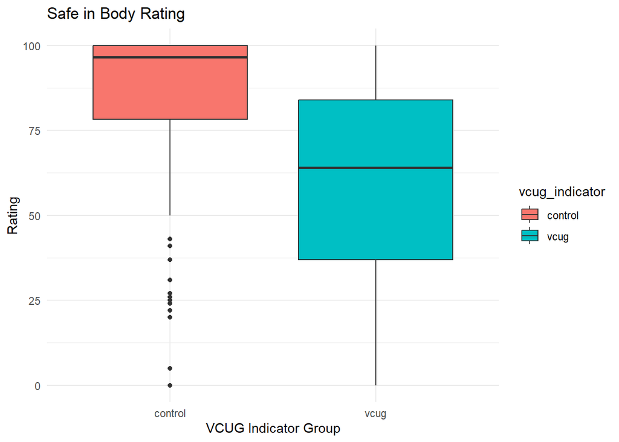

```r
# Rating Boxplot
ggplot(safety, aes(x = vcug_indicator, y = safe_body_scale, fill = vcug_indicator)) +
  geom_boxplot() +
  labs(title = "Safe in Body Rating",
       x = "VCUG Indicator Group",
       y = "Rating") +
  theme_minimal()
```

*I enjoy consensual sexual intercourse and/or foreplay.*

```r
# Summary statistics stratified by VCUG indicator
esex_stats <- safety %>%
  group_by(vcug_indicator) %>%
  summarise(
    esex_mean = mean(enjoy_sex, na.rm = TRUE),
    esex_med = median(enjoy_sex, na.rm = TRUE),
)
esex_stats
```

```
# A tibble: 2 × 3
  vcug_indicator esex_mean esex_med
  <fct>              <dbl>    <int>
1 control             84.7       98
2 vcug                61.7       64
```

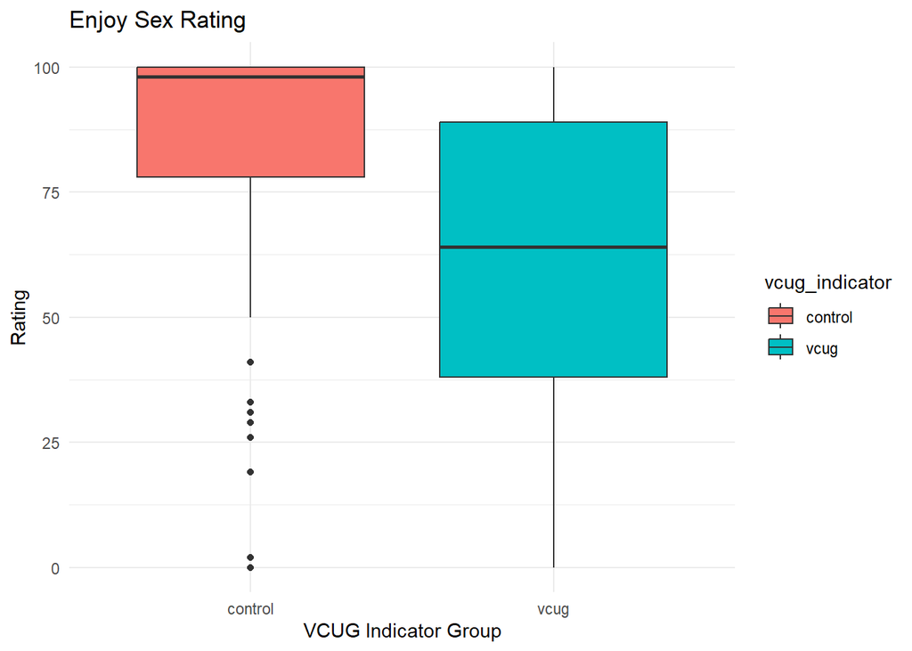

```r
# Rating Boxplot
ggplot(safety, aes(x = vcug_indicator, y = enjoy_sex, fill = vcug_indicator)) +
  geom_boxplot() +
  labs(title = "Enjoy Sex Rating",
       x = "VCUG Indicator Group",
       y = "Rating") +
  theme_minimal()
```

- **Takeaways:** report lower mean values and distribution across all categories being lower for VCUG group than control group.

## 5 Conclusion

Overall, this work substantially supported my research endeavors outside of class. As part of my collaboration with Penn’s Biostatistics Analysis Center, my primary goal was to use R to produce a clean, revised, and user-friendly product with which to submit to the Center for further analysis. The goal here was really to look closely at my data for the first time - to understand what I had collected over the last nine months, and decide what fields were usable and worth further exploration. Scott and I have been most interested in the demographics of this dataset, because it will help us decide what we can truly assess and publish from this limited (and source-biased) sample set. Based on these results, I can provide the following information to the Biostatistics Analysis Center:

**Age distribution is as follows**: 18–24 (16%), 25–34 (64%), 35–44 (12%), 45–54 (5%), 55–64 (4%), and 65+ (>1%).

**The most dominant education group was people with a bachelor’s degree** (39%) followed by those with a master’s degree (18%).

**Race/ethnicity:** The study data predominantly includes White (73%) followed by Black or African American respondents (7%) - this is not diverse whatsoever and needs improvement.

**Two groups were formed** to identify VCUG patients (N=204, 61%) and non-VCUG controls (N=130, 39%)

**Source distribution**: My survey source distribution is well-distributed, which is encouraging. It should be noted (this analysis was performed manually in Excel due to the nature of free-form entries) that nearly every VCUG respondent who discovered this survey via Reddit (17%) found it through the subreddit r/VCUGTrauma or a related medical trauma subreddit. This suggests a heavy amount of trauma-leaning bias in the vcug sample group.

**Overall, I can assert the following initial takeaways about the results of the study:**

- Both physical and mental health are self-reported lower in the VCUG group than the control group.

- The VCUG group returned a larger proportion of diagnoses or supposed diagnoses in every single category.

- There’s a substantial degree of undiagnosed but presumed sequelae in the VCUG group compared to control (hypertonic pelvic floor, PGAD, etc)

- A larger proportion of the VCUG group reports they will never see a urologist or gynecologist vs. control groups, though both groups are open to seeing physicians for regular care. The most substantial difference noted is that 20% of VCUG females report that they will never get a pap smear, vs. 1% of the control group.

- The VCUG group reports lower mean scores across all “safety” categories (going to the bathroom, safe in one’s own body, etc.) vs control group.

I will use these results to discuss the next logical analysis steps with Scott, and look to publish findings in May 2024. While this exploration may have been more simple compared to all of R’s capabilities, this analysis played a crucial role in my ability to understand, interpret, and communicate my initial findings to my collaborators for next steps.